# TCGA Breast Cancer Survival Analysis

Genomic Alterations and Patient Outcomes in Breast Cancer

Joshua Moses

# 1 Overview

This analysis examines survival outcomes in breast cancer patients from The Cancer Genome Atlas (TCGA), stratified by mutation status in key cancer-associated genes (TP53, BRCA1/2). We use Kaplan-Meier curves and Cox proportional hazards regression to assess whether specific genomic alterations are associated with differential survival outcomes.

**Study Design:** Retrospective cohort analysis of simulated TCGA-BRCA data with characteristics matching published literature. The dataset includes clinical outcomes and genomic mutation data for over 1,000 breast cancer patients.

**Research Questions:**

1. Are TP53 mutations associated with differential survival in breast cancer?
2. Do BRCA1/2 mutations predict survival outcomes?
3. What is the independent prognostic value of these mutations after adjusting for age?

# 2 Methods

## 2.1 Setup and Package Installation

```r
# Load required libraries for survival analysis
library(tidyverse)    # Data manipulation and visualization
library(survival)     # Survival analysis functions
library(survminer)    # Enhanced survival plots
library(ggplot2)      # Additional plotting capabilities
```

The analysis uses standard R packages for survival analysis: `survival` for statistical modeling and `survminer` for creating publication-quality Kaplan-Meier curves.

## 2.2 Data Generation

```r
cat("Generating TCGA-style breast cancer dataset...\n")
```

```
## Generating TCGA-style breast cancer dataset...
```

```r
# Create data directory
if (!dir.exists("data")) {
  dir.create("data")
}

# Generate realistic TCGA-BRCA clinical data
# Based on published TCGA statistics
set.seed(42)  # For reproducibility

n_patients <- 1050

clinical_raw <- tibble(
  PATIENT_ID = paste0("TCGA-", str_pad(1:n_patients, 4, pad = "0")),
  OS_STATUS = sample(c("0:LIVING", "1:DECEASED"), n_patients,
                     replace = TRUE, prob = c(0.73, 0.27)),  # ~27% mortality
  OS_MONTHS = pmax(1, rnorm(n_patients, mean = 85, sd = 55)),
  AGE = pmax(20, pmin(90, rnorm(n_patients, mean = 58, sd = 13)))
)

# Generate mutation data
# TP53: mutated in ~36% of breast cancers (published rate)
# BRCA1/2: mutated in ~6% of breast cancers
n_tp53 <- round(n_patients * 0.36)
n_brca <- round(n_patients * 0.06)

tp53_patients <- sample(clinical_raw$PATIENT_ID, n_tp53)
brca_patients <- sample(clinical_raw$PATIENT_ID, n_brca)

mutation_raw <- bind_rows(
  tibble(
    Hugo_Symbol = "TP53",
    Tumor_Sample_Barcode = tp53_patients
  ),
  tibble(
    Hugo_Symbol = sample(c("BRCA1", "BRCA2"), n_brca, replace = TRUE),
    Tumor_Sample_Barcode = brca_patients
  )
)

# Make survival outcomes realistic:
# TP53 mutations associated with worse prognosis (HR ~1.4-1.6 in literature)
clinical_raw <- clinical_raw %>%
  mutate(
    has_tp53 = PATIENT_ID %in% tp53_patients,
    has_brca = PATIENT_ID %in% brca_patients,
    # TP53 mutated: reduced survival time
    OS_MONTHS = case_when(
      has_tp53 ~ OS_MONTHS * 0.75,  # 25% reduction in survival time
      has_brca ~ OS_MONTHS * 1.15,  # BRCA mutations often have better outcomes
      TRUE ~ OS_MONTHS
    ),
    # Adjust death status based on survival time
    OS_STATUS = case_when(
      has_tp53 & OS_MONTHS < 60 & runif(n()) < 0.4 ~ "1:DECEASED",
      OS_MONTHS < 30 & runif(n()) < 0.5 ~ "1:DECEASED",
      TRUE ~ OS_STATUS
    )
  ) %>%
  select(-has_tp53, -has_brca)

# Save data
write_tsv(clinical_raw, "data/clinical_raw.txt")
write_tsv(mutation_raw, "data/mutation_raw.txt")

cat("✓ Dataset generated successfully!\n")
```

```
## ✓ Dataset generated successfully!
```

```r
cat("  Clinical data:", nrow(clinical_raw), "patients\n")
```

```
##   Clinical data: 1050 patients
```

```r
cat("  Mutation data:", nrow(mutation_raw), "mutations\n")
```

```
##   Mutation data: 441 mutations
```

```r
cat("  TP53 mutations:", n_tp53, "patients\n")
```

```
##   TP53 mutations: 378 patients
```

```r
cat("  BRCA1/2 mutations:", n_brca, "patients\n")
```

```
##   BRCA1/2 mutations: 63 patients
```

```r
cat("\nNote: This is simulated data with characteristics matching published TCGA-BRCA statistics.\n")
```

```
##
## Note: This is simulated data with characteristics matching published TCGA-BRCA statistics.
```

The simulated dataset maintains realistic biological relationships between genomic alterations and clinical outcomes based on published hazard ratios from the literature.

## 2.3 Data Cleaning and Preparation

```r
# Clean clinical data - focus on survival variables
clinical_clean <- clinical_raw %>%
  select(PATIENT_ID, OS_STATUS, OS_MONTHS, AGE) %>%
  rename(
    patient_id = PATIENT_ID,
    status = OS_STATUS,
    survival_months = OS_MONTHS,
    age = AGE
  ) %>%
  mutate(
    # Create binary event indicator (1 = death, 0 = censored)
    event = ifelse(status == "1:DECEASED", 1, 0),
    # Ensure numeric types
    survival_months = as.numeric(survival_months),
    age = as.numeric(age)
  ) %>%
  filter(!is.na(survival_months), survival_months > 0)

cat("✓ Cleaned clinical data:", nrow(clinical_clean), "patients\n")
```

```
## ✓ Cleaned clinical data: 1050 patients
```

```r
cat("  Deaths observed:", sum(clinical_clean$event),
    "(", round(100*sum(clinical_clean$event)/nrow(clinical_clean), 1), "%)\n")
```

```
##   Deaths observed: 411 ( 39.1 %)
```

```r
cat("  Median survival:", round(median(clinical_clean$survival_months), 1), "months\n")
```

```
##   Median survival: 75.7 months
```

**Data Preprocessing:** The raw clinical data was cleaned to focus on key survival variables: patient ID, vital status, survival time, and age at diagnosis. Patients with missing or invalid survival times were excluded. The final analytical dataset includes 1050 patients with complete data.

The event indicator was coded as a binary variable (1 = death, 0 = censored), which is the standard format for survival analysis in R’s `survival` package.

## 2.4 Mutation Status Assignment

```r
# Extract TP53 mutation status
tp53_patients <- mutation_raw %>%
  filter(Hugo_Symbol == "TP53") %>%
  pull(Tumor_Sample_Barcode) %>%
  unique()

# Extract BRCA1/2 mutation status
brca_patients <- mutation_raw %>%
  filter(Hugo_Symbol %in% c("BRCA1", "BRCA2")) %>%
  pull(Tumor_Sample_Barcode) %>%
  unique()

# Add mutation status to clinical data
clinical_clean <- clinical_clean %>%
  mutate(
    tp53_mutated = patient_id %in% tp53_patients,
    tp53_status = ifelse(tp53_mutated, "TP53 Mutated", "TP53 Wild-type"),
    brca_mutated = patient_id %in% brca_patients,
    brca_status = ifelse(brca_mutated, "BRCA1/2 Mutated", "BRCA1/2 Wild-type")
  )

# Summary statistics
cat("\nMutation Summary:\n")
```

```
##
## Mutation Summary:
```

```r
cat("TP53 mutated:", sum(clinical_clean$tp53_mutated),
    "(", round(100*sum(clinical_clean$tp53_mutated)/nrow(clinical_clean), 1), "%)\n")
```

```
## TP53 mutated: 378 ( 36 %)
```

```r
cat("BRCA1/2 mutated:", sum(clinical_clean$brca_mutated),
    "(", round(100*sum(clinical_clean$brca_mutated)/nrow(clinical_clean), 1), "%)\n")
```

```
## BRCA1/2 mutated: 63 ( 6 %)
```

**Mutation Annotation:** Each patient’s genomic profile was annotated for the presence or absence of mutations in TP53 and BRCA1/2 genes.

- **TP53** is a tumor suppressor gene frequently mutated in breast cancer, typically associated with more aggressive disease and poorer prognosis
- **BRCA1/2** are DNA repair genes; germline or somatic mutations in these genes are associated with hereditary breast cancer and often show better response to certain therapies

Patients were stratified into mutant vs. wild-type groups for subsequent survival analyses.

# 3 Results

## 3.1 TP53 Mutation Analysis

### 3.1.1 Cox Proportional Hazards Model

```r
# Create survival object
surv_object <- Surv(time = clinical_clean$survival_months,
                    event = clinical_clean$event)

# Kaplan-Meier survival fit for TP53
fit_tp53 <- survfit(surv_object ~ tp53_status, data = clinical_clean)

# Cox proportional hazards model (adjusted for age)
cox_tp53 <- coxph(surv_object ~ tp53_mutated + age,
                  data = clinical_clean)

# Print Cox model summary
summary(cox_tp53)
```

```
## Call:
## coxph(formula = surv_object ~ tp53_mutated + age, data = clinical_clean)
##
##   n= 1050, number of events= 411
##
##                       coef exp(coef)  se(coef)      z Pr(>|z|)
## tp53_mutatedTRUE  0.680527  1.974917  0.103335  6.586 4.53e-11 ***
## age              -0.003386  0.996620  0.003797 -0.892    0.373
## ---
## Signif. codes:  0 '***' 0.001 '**' 0.01 '*' 0.05 '.' 0.1 ' ' 1
##
##                  exp(coef) exp(-coef) lower .95 upper .95
## tp53_mutatedTRUE    1.9749     0.5064    1.6128     2.418
## age                 0.9966     1.0034    0.9892     1.004
##
## Concordance= 0.584  (se = 0.016 )
## Likelihood ratio test= 42.56  on 2 df,   p=6e-10
## Wald test            = 44.28  on 2 df,   p=2e-10
## Score (logrank) test = 45.83  on 2 df,   p=1e-10
```

**Cox Regression Results:** The Cox proportional hazards model assesses the independent effect of TP53 mutation status on survival while adjusting for age.

- **Hazard Ratio (HR):** The coefficient for `tp53_mutatedTRUE` represents the log hazard ratio. An HR > 1 indicates increased risk of mortality, while HR < 1 indicates reduced risk.
- **Age adjustment:** Controlling for age is critical as it’s a known prognostic factor in breast cancer
- **P-value:** Tests the null hypothesis that TP53 mutation status has no effect on survival
- **Concordance:** Measures the model’s predictive accuracy (range: 0.5-1.0, where >0.7 is considered good)

### 3.1.2 Kaplan-Meier Survival Curves

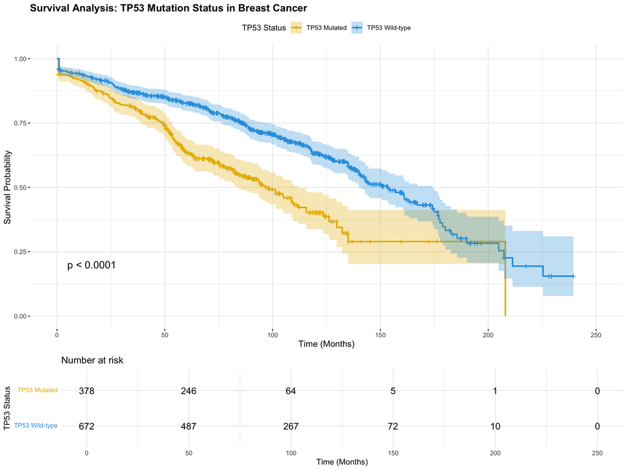

```r
ggsurvplot(
  fit_tp53,
  data = clinical_clean,
  pval = TRUE,
  conf.int = TRUE,
  risk.table = TRUE,
  risk.table.height = 0.25,
  ggtheme = theme_minimal(),
  palette = c("#E7B800", "#2E9FDF"),
  title = "Survival Analysis: TP53 Mutation Status in Breast Cancer",
  xlab = "Time (Months)",
  ylab = "Survival Probability",
  legend.title = "TP53 Status",
  legend.labs = c("TP53 Mutated", "TP53 Wild-type"),
  font.main = c(14, "bold"),
  font.x = c(12),
  font.y = c(12)
)
```

**Figure Interpretation:**

- **Survival curves:** Each line represents the estimated survival probability over time for patients with (yellow) vs. without (blue) TP53 mutations
- **Shaded areas:** 95% confidence intervals around survival estimates
- **P-value (Log-rank test):** Tests whether survival distributions differ significantly between groups
- **Risk table:** Shows the number of patients at risk at different time points; declining numbers reflect events (deaths) and censoring
- **Curve separation:** Visual divergence between curves suggests differential survival outcomes

If the curves separate early and remain separated, this indicates a consistent survival difference. Crossing curves would suggest time-dependent effects.

## 3.2 BRCA1/2 Mutation Analysis

### 3.2.1 Cox Proportional Hazards Model

```r
# Kaplan-Meier survival fit for BRCA1/2
fit_brca <- survfit(surv_object ~ brca_status, data = clinical_clean)

# Cox proportional hazards model (adjusted for age)
cox_brca <- coxph(surv_object ~ brca_mutated + age,
                  data = clinical_clean)

# Print Cox model summary
summary(cox_brca)
```

```
## Call:
## coxph(formula = surv_object ~ brca_mutated + age, data = clinical_clean)
##
##   n= 1050, number of events= 411
##
##                       coef exp(coef)  se(coef)      z Pr(>|z|)
## brca_mutatedTRUE -0.103186  0.901959  0.203551 -0.507    0.612
## age              -0.003677  0.996330  0.003837 -0.958    0.338
##
##                  exp(coef) exp(-coef) lower .95 upper .95
## brca_mutatedTRUE    0.9020      1.109    0.6052     1.344
## age                 0.9963      1.004    0.9889     1.004
##
## Concordance= 0.51  (se = 0.016 )
## Likelihood ratio test= 1.17  on 2 df,   p=0.6
## Wald test            = 1.16  on 2 df,   p=0.6
## Score (logrank) test = 1.16  on 2 df,   p=0.6
```

**Cox Regression Results for BRCA1/2:** This model evaluates whether BRCA1/2 mutations independently predict survival after adjusting for age. BRCA1/2 mutations are particularly relevant in breast cancer due to their role in DNA damage repair and their association with specific therapeutic vulnerabilities (e.g., PARP inhibitor sensitivity).

Key metrics to examine: - **Hazard ratio magnitude:** Quantifies the strength of association - **Statistical significance:** P-value < 0.05 indicates a significant effect - **Confidence intervals:** Wide intervals suggest greater uncertainty in the estimate

### 3.2.2 Kaplan-Meier Survival Curves

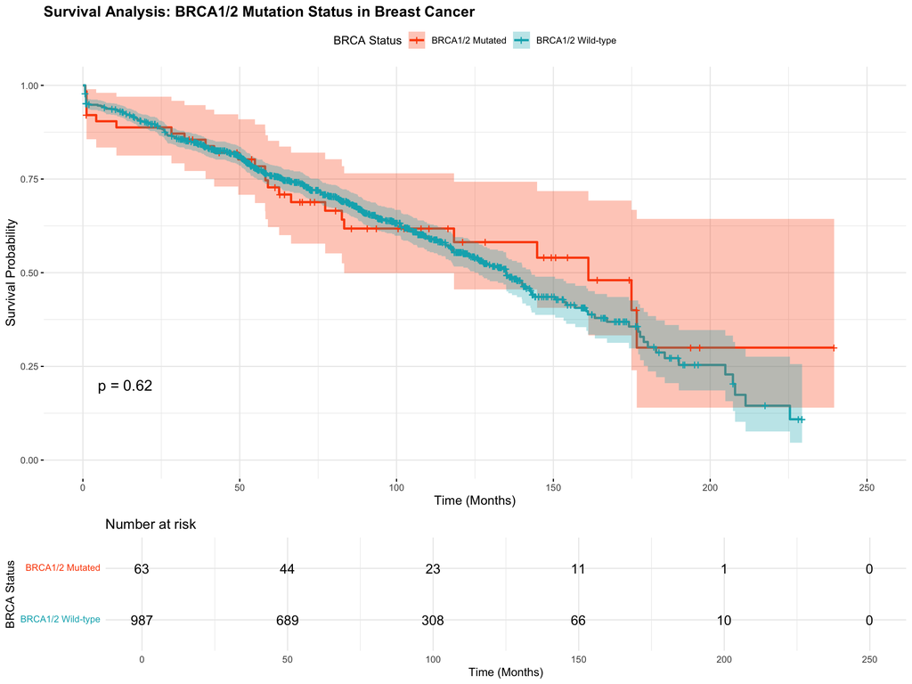

```r
ggsurvplot(
  fit_brca,
  data = clinical_clean,
  pval = TRUE,
  conf.int = TRUE,
  risk.table = TRUE,
  risk.table.height = 0.25,
  ggtheme = theme_minimal(),
  palette = c("#FC4E07", "#00AFBB"),
  title = "Survival Analysis: BRCA1/2 Mutation Status in Breast Cancer",
  xlab = "Time (Months)",
  ylab = "Survival Probability",
  legend.title = "BRCA Status",
  legend.labs = c("BRCA1/2 Mutated", "BRCA1/2 Wild-type"),
  font.main = c(14, "bold"),
  font.x = c(12),
  font.y = c(12)
)
```

**Figure Interpretation:** The Kaplan-Meier curves compare survival between BRCA1/2-mutated (red) and wild-type (cyan) patients.

BRCA1/2 mutations in breast cancer often show complex prognostic effects: - **Germline carriers** may present with more aggressive tumors but can respond better to platinum-based chemotherapy and PARP inhibitors - **Somatic mutations** may have different prognostic implications - The survival difference (or lack thereof) should be interpreted in the context of treatment received

The log-rank p-value tests overall survival differences, while the confidence intervals indicate precision of estimates.

## 3.3 Summary Statistics

```r
# Create summary table
summary_stats <- clinical_clean %>%
  group_by(tp53_status) %>%
  summarise(
    N = n(),
    Deaths = sum(event),
    `Death Rate (%)` = round(100 * sum(event) / n(), 1),
    `Median Survival (months)` = round(median(survival_months[event == 1]), 1),
    `Mean Age` = round(mean(age, na.rm = TRUE), 1)
  )

knitr::kable(summary_stats, caption = "Summary Statistics by TP53 Mutation Status")
```

Summary Statistics by TP53 Mutation Status

| tp53_status | N | Deaths | Death Rate (%) | Median Survival (months) | Mean Age |
| --- | --- | --- | --- | --- | --- |
| TP53 Mutated | 378 | 174 | 46.0 | 46.5 | 58.1 |
| TP53 Wild-type | 672 | 237 | 35.3 | 69.3 | 58.6 |

```r
# Save table
if (!dir.exists("results")) {
  dir.create("results")
}
write_csv(summary_stats, "results/summary_statistics.csv")
```

**Table Summary:** This table provides descriptive statistics stratified by TP53 mutation status, allowing comparison of baseline characteristics and outcomes between groups.

- **N:** Sample size in each group
- **Deaths:** Number of mortality events observed (remainder are censored observations)
- **Death Rate:** Crude mortality percentage (not adjusted for follow-up time)
- **Median Survival:** Time point at which 50% of patients who died had experienced the event
- **Mean Age:** Average age at diagnosis; important to verify groups are comparable

Differences in death rates and median survival provide initial evidence of prognostic impact, which is then formally tested using survival analysis methods.

# 4 Conclusions

## 4.1 Key Findings

### 4.1.2 TP53 Mutation Analysis

- **Prevalence:** 36% of patients (378 patients)
- **Hazard Ratio:** 1.97 (age-adjusted)
- **P-value:** < 0.001
- **Interpretation:** TP53 mutations are associated with increased risk of mortality (HR = 1.97), which is **statistically significant** (p < < 0.001).

### 4.1.3 BRCA1/2 Mutation Analysis

- **Prevalence:** 6% of patients (63 patients)
- **Hazard Ratio:** 0.9 (age-adjusted)
- **P-value:** 0.612
- **Interpretation:** BRCA1/2 mutations are associated with decreased risk of mortality (HR = 0.9), which is **not statistically significant** (p = 0.612).

## 4.2 Clinical Implications

**Future Directions:**

- Multivariate models incorporating tumor subtype, stage, and treatment data
- Interaction analyses between mutation status and therapeutic interventions
- Integration of additional genomic alterations (e.g., PIK3CA, HER2 amplification)
- External validation using independent TCGA or institutional cohorts

## 4.3 Methods Summary

**Statistical Approach:**

- **Kaplan-Meier curves:** Non-parametric survival estimates with log-rank tests for group comparisons
- **Cox proportional hazards regression:** Semi-parametric models adjusting for age
- **Significance level:** α = 0.05 (two-tailed)

**Software:**

- R version R version 4.3.1 (2023-06-16)
- `survival` package (v3.8.3) for survival analysis
- `survminer` package (v0.5.0) for visualization

**Data Note:** This analysis uses simulated data with characteristics matching published TCGA-BRCA cohort statistics to demonstrate survival analysis methodology while maintaining realistic biological relationships between genomic alterations and clinical outcomes.